# week 10: final countdown

missing data

```r
library(tidyverse)
library(psych)
library(cowplot)
library(patchwork)
library(here)
library(brms)
library(tidybayes)
library(ggdag)
library(mice) # new package!
```

## missing data as a causal problem

From RM:

> The fact that a variable has an unobserved value is still an observation. It is data, just with a very special value. The meaning of this value depends upon the context. Consider for example a questionnaire on personal income. If some people refuse to fill in their income, this may be associated with low (or high) income. Therefore a model that tries to predict the missing values can be enlightening. In ecology, the absence of an observation of a species is a subtle kind of observation. It could mean the species isn’t there. Or it could mean it is there but you didn’t see it. An entire category of models, occupancy models, exists to take this duality into account. Missing values are always produced by some process, and thinking about that process can sometimes solve big problems.

### DAG ate my homework

```r
# panel a
dag_coords <-
  tibble(name = c("S", "H", "Hs", "D"),
         x    = c(1, 2, 2, 1),
         y    = c(2, 2, 1, 1))

p1 <-
  dagify(H  ~ S,
         Hs ~ H + D,
         coords = dag_coords) %>%
  tidy_dagitty() %>%
  mutate(color = ifelse(name == "H", "a", "b")) %>%
  ggplot(aes(x = x, y = y, xend = xend, yend = yend)) +
  geom_dag_point(aes(color=color), size = 7, show.legend = F) +
  geom_dag_text(label = c("D", "H", "H*", "S")) +  # Corrected order
  geom_dag_edges() +
  theme(axis.line = element_blank(),
        axis.text = element_blank(),
        axis.ticks = element_blank(),
        axis.title = element_blank())

# panel b
p2 <-
  dagify(H  ~ S,
         Hs ~ H + D,
         D  ~ S,
         coords = dag_coords) %>%
  tidy_dagitty() %>%
  mutate(color = ifelse(name == "H", "a", "b")) %>%
  ggplot(aes(x = x, y = y, xend = xend, yend = yend)) +
  geom_dag_point(aes(color=color), size = 7, show.legend = F) +
  geom_dag_text(label = c("D", "H", "H*", "S")) +  # Corrected order
  geom_dag_edges() +
  theme(axis.line = element_blank(),
        axis.text = element_blank(),
        axis.ticks = element_blank(),
        axis.title = element_blank())

# panel c - coordinates for 5 nodes
dag_coords_c <-
  tibble(name = c("S", "H", "Hs", "D", "X"),
         x    = c(1, 2, 2, 1, 1.5),
         y    = c(2, 2, 1, 1, 1.5))

p3 <-
  dagify(H  ~ S + X,
         Hs ~ H + D,
         D  ~ X,
         coords = dag_coords_c) %>%
  tidy_dagitty() %>%
  mutate(color = ifelse(name %in% c("H", "X"), "a", "b")) %>%
  ggplot(aes(x = x, y = y, xend = xend, yend = yend)) +
  geom_dag_point(aes(color=color), size = 7, show.legend = F) +
  geom_dag_text(label = c("D", "H", "H*", "S", "X")) +  # Corrected order
  geom_dag_edges() +
  theme(axis.line = element_blank(),
        axis.text = element_blank(),
        axis.ticks = element_blank(),
        axis.title = element_blank())

# panel d
p4 <-
  dagify(H  ~ S,
         Hs ~ H + D,
         D  ~ H,
         coords = dag_coords) %>%
  tidy_dagitty() %>%
  mutate(color = ifelse(name == "H", "a", "b")) %>%
  ggplot(aes(x = x, y = y, xend = xend, yend = yend)) +
  geom_dag_point(aes(color=color), size = 7, show.legend = F) +
  geom_dag_text(label = c("D", "H", "H*", "S")) +  # Corrected order
  geom_dag_edges() +
  theme(axis.line = element_blank(),
        axis.text = element_blank(),
        axis.ticks = element_blank(),
        axis.title = element_blank())

(p1 + p2 + p3 + p4) +
  plot_annotation(tag_levels = "a", tag_prefix = "(", tag_suffix = ")") &
  theme(plot.margin = margin(0.15, 0.15, 0.15, 0.15, "in"))
```

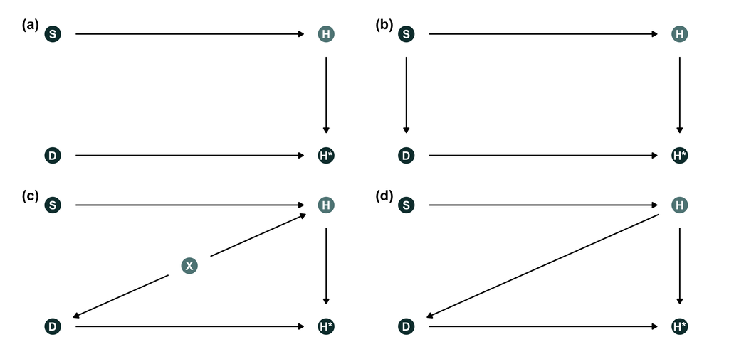

## an example: nhanes

- `age`– participants’ age
- `bmi` – body mass index<sup>1</sup>
- `hyp` – hypertensive
- `chl` –total serum cholesterol

```r
data(nhanes, package="mice")
d <- nhanes
psych::describe(d, fast=T)
```

```
    vars  n   mean    sd median   min   max range  skew kurtosis    se
age    1 25   1.76  0.83   2.00   1.0   3.0   2.0  0.44    -1.47  0.17
bmi    2 16  26.56  4.22  26.75  20.4  35.3  14.9  0.39    -0.83  1.05
hyp    3 17   1.24  0.44   1.00   1.0   2.0   1.0  1.14    -0.73  0.11
chl    4 15 191.40 45.22 187.00 113.0 284.0 171.0 -0.09    -0.43 11.67
```

[^1]: caveats about BMI as a measure of anything

```r
# Define coordinates for the nodes
dag_coords <- tibble(
  name = c("age", "chl", "bmi"),
  x    = c(1, 2, 3),
  y    = c(2, 2, 1)
)

# Create the DAG
dagify(
  bmi ~ age + chl,
  chl ~ age,
  coords = dag_coords
) %>%
  tidy_dagitty() %>%
  ggplot(aes(x = x, y = y, xend = xend, yend = yend)) +
  geom_dag_point(size = 10) +
  geom_dag_text(size = 4) +
  geom_dag_edges(arrow_directed = grid::arrow(length = grid::unit(10, "pt"), type = "closed")) +
  theme_dag()
```

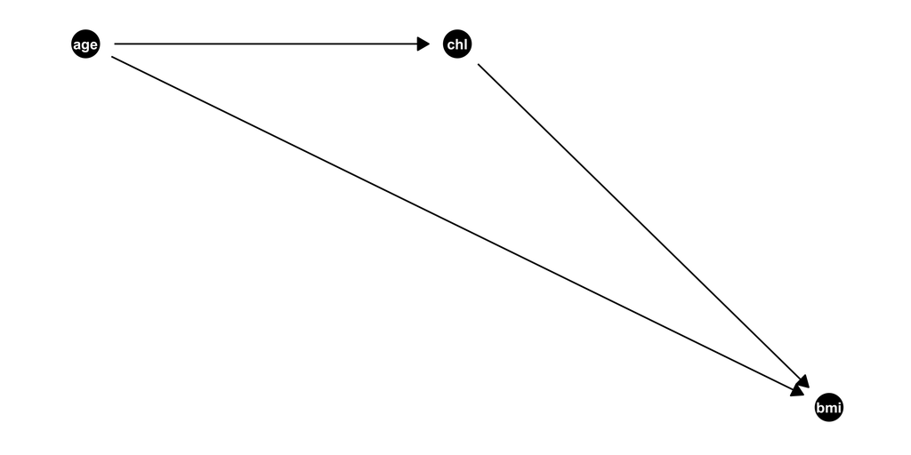